# Practica_1_Analisis_Datasaurus

Andres

2024-09-23

[figure not shown]

## Practica DataSaurus

Nombre: Nixon Andres Alvarado Calle

Materia: Mineria de Datos

En esta practica se va a realizar varias actividades para conocer mas sobre el lenguaje R, a continuacion las actividades que se realizaron:

Este conjunto de datos fue creado por Alberto Cairo y presentado en el proyecto Datasaurus, desarrollado por Justin Matejka y George Fitzmaurice en 2017. El propósito del dataset es demostrar la relevancia de visualizar los datos, más allá de simplemente analizar las estadísticas descriptivas.

1. Cargamos las librerias:

```r
library(datasauRus)
library(dplyr)
```

```r
library(ggplot2)
```

2. Mostramos un resumen estadistico del dataset:

```r
datasaurus_dozen %>%
  group_by(dataset) %>%
  summarize( mean_x = mean(x),
             mean_y = mean(y),
             std_dev_x = sd(x),
             std_dev_y = sd(y),
             corr_x_y = cor(x,y))
```

```
## # A tibble: 13 × 6
##    dataset    mean_x mean_y std_dev_x std_dev_y corr_x_y
##    <chr>       <dbl>  <dbl>     <dbl>     <dbl>    <dbl>
##  1 away         54.3   47.8      16.8      26.9  -0.0641
##  2 bullseye     54.3   47.8      16.8      26.9  -0.0686
##  3 circle       54.3   47.8      16.8      26.9  -0.0683
##  4 dino         54.3   47.8      16.8      26.9  -0.0645
##  5 dots         54.3   47.8      16.8      26.9  -0.0603
##  6 h_lines      54.3   47.8      16.8      26.9  -0.0617
##  7 high_lines   54.3   47.8      16.8      26.9  -0.0685
##  8 slant_down   54.3   47.8      16.8      26.9  -0.0690
##  9 slant_up     54.3   47.8      16.8      26.9  -0.0686
## 10 star         54.3   47.8      16.8      26.9  -0.0630
## 11 v_lines      54.3   47.8      16.8      26.9  -0.0694
## 12 wide_lines   54.3   47.8      16.8      26.9  -0.0666
## 13 x_shape      54.3   47.8      16.8      26.9  -0.0656
```

3. Graficamos

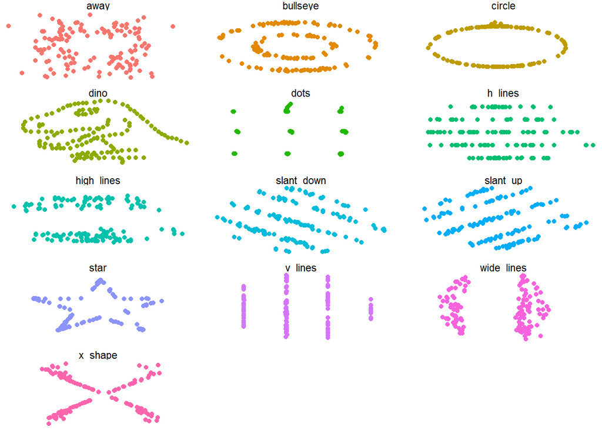

```r
ggplot(datasaurus_dozen,aes(x=x,y=y,colour=dataset))+geom_point()+theme_void()+theme(legend.position = "none")+ facet_wrap(~dataset, ncol=3)
```

4. Filtramos los datos segun lo entregado por el docente en este cado v_lines

```r
dfgrupo<-datasaurus_dozen %>%
  filter(dataset=="v_lines")
dfgrupo
```

```
## # A tibble: 142 × 3
##    dataset     x     y
##    <chr>   <dbl> <dbl>
##  1 v_lines  50.5  93.2
##  2 v_lines  50.3  97.6
##  3 v_lines  50.2  99.7
##  4 v_lines  50.3  90.0
##  5 v_lines  50.5  90.0
##  6 v_lines  30.5  82.1
##  7 v_lines  30.5  82.3
##  8 v_lines  30.5  77.7
##  9 v_lines  30.5  79.8
## 10 v_lines  30.5  68.3
## # ℹ 132 more rows
```

5. Calcular la regresion de grupo v_lines

```r
#Calcular la regresión lineal
regresion <- lm(y~x,data=dfgrupo)
#Mostrar el resumen de la regresion
summary(regresion)
```

```
##
## Call:
## lm(formula = y ~ x, data = dfgrupo)
##
## Residuals:
##     Min      1Q  Median      3Q     Max
## -44.605 -24.261  -1.092  18.186  51.402
##
## Coefficients:
##             Estimate Std. Error t value Pr(>|t|)
## (Intercept)  53.8908     7.6903   7.008 9.38e-11 ***
## x            -0.1116     0.1354  -0.824    0.412
## ---
## Signif. codes:  0 '***' 0.001 '**' 0.01 '*' 0.05 '.' 0.1 ' ' 1
##
## Residual standard error: 26.97 on 140 degrees of freedom
## Multiple R-squared:  0.004823,   Adjusted R-squared:  -0.002286
## F-statistic: 0.6784 on 1 and 140 DF,  p-value: 0.4115
```

6. graficamos la regresion

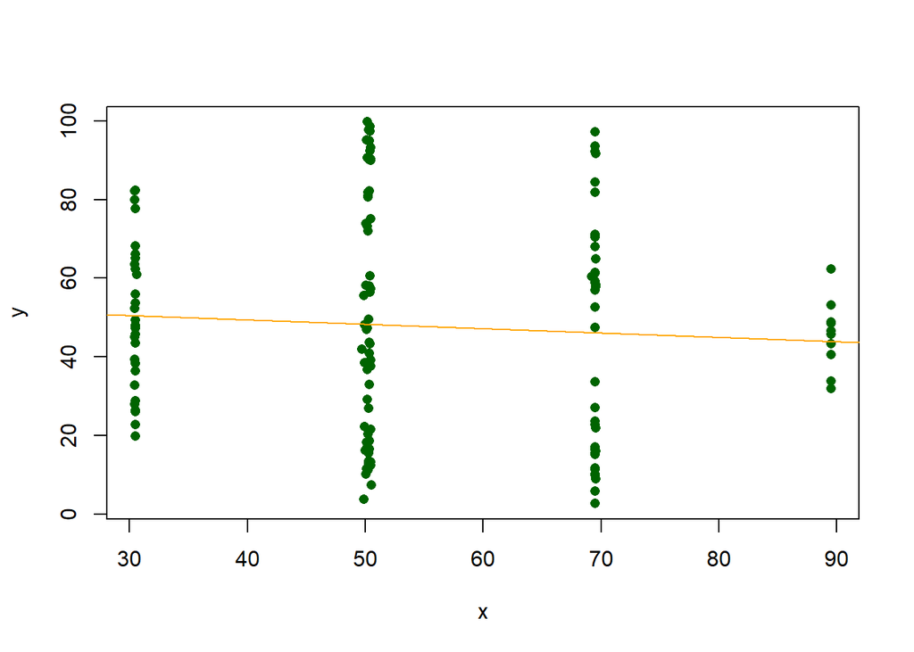

```r
#graficamos los puntos y la linea de regresión
plot(dfgrupo$x, dfgrupo$y, xlab='x', ylab='y', col='darkgreen',pch = 16)
abline(regresion, col='orange')
```

7. graficamos la regresion con otra herramienta

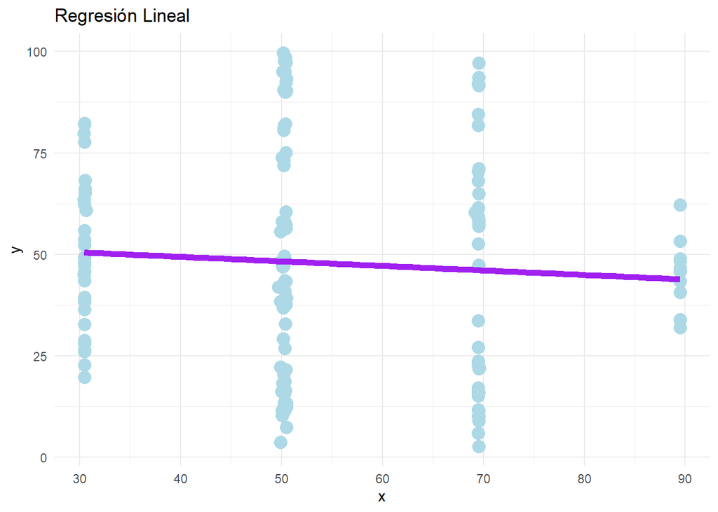

```r
# Graficar los puntos y la línea de regresión usando ggplot2 y geom_smooth
ggplot(dfgrupo, aes(x = x, y = y)) +
  geom_point(color = 'lightblue', size =4 ) +  # Puntos en color azul y tamaño 2
  geom_smooth(method = 'lm', color = 'purple', se = FALSE,size=2) +  # Línea de regresión en color rojo
  labs(title = 'Regresión Lineal', x = 'x', y = 'y') +  # Títulos y etiquetas de los ejes
  theme_minimal()  # Tema para mejorar la apariencia
```

8. Conclusión

El conjunto DataSaurus, creado por Alberto Cairo y presentado en el proyecto de Justin Matejka y George Fitzmaurice, demuestra que diferentes distribuciones de datos pueden tener estadísticas similares, pero presentar formas visuales completamente distintas. Al enfocarnos en el subconjunto de datos `v_lines`, realizamos un análisis de regresión lineal y graficamos los resultados, tanto utilizando funciones base de R como con el paquete `ggplot2`.

El uso de `ggplot2` nos permitió generar visualizaciones más estéticas y claras, lo que subraya el poder de la visualización en la minería de datos. Este enfoque no solo facilita la identificación de patrones y relaciones en los datos, sino que también nos ayuda a comunicar nuestros hallazgos de manera más efectiva.